# AN 588 Homework 2

Jimmy Erkens

2023-10-18

[figure not shown]

> NOTE: Soooo this is a red howler monkey (*Alouatta seniculus*), not a titi monkey (which are the genera *Plecturocebus*, *Cheracebus*, and *Callicebus*)! Please take AN/BI 336 when I next teach it, we’ll go over this!

# 1 Libraries

Load in the necessary libraries:

```r
library(prettydoc)
library(yaml)
library(tidyverse)
library(tinytex) # install.packages("tinytex") <3
```

**Very kind and forward-thinking of you to provide the packages, thank you! -AJL**

> Agreed - this is best practices for setting up a readable and reproducible Rmarkdown file.

# 2 Questions

## 2.1 Initializations

**I like the nested toc structure. -AJL** The number of titi monkey calls in a 2 hour window is represented by X. X ~ Pois($\lambda$ = 15)

## 2.2 What is the probability that she will hear more than 8 calls during any given session?

We can use `ppois()` to find out cumulative probabilities!

```r
ppois(q = 8, lambda = 15, lower.tail = F) # NOTE lower.tail = F does not include 8, so we must start at 7
```

```
## [1] 0.9625535
```

```r
# Double note!
```

> Yeah, we get the same answer with 1-ppois, but only if using q = 8. I do think you can use q = 8 with ppois and get to this answer… can you show me the documentation that suggests we’d need to use q = 7? Seems odd to me.

## 2.3 What is the probability that she will hear no calls in a session?

Again, we can use `ppois()` to find out cumulative probabilities!

```r
ppois(q = 0, lambda = 15, lower.tail = T) # 0 or less calls in a session
```

```
## [1] 3.059023e-07
```

The probability we hear 0 calls is 3.059 x 10^-7.

> This works because ppois is accumulating from 0 to 0, yes. I might recommend dpois as a better choice since this is actually requesting a point value.

## 2.4 What is the probability that she will hear exactly 3 calls in a session?

We can use `dpois()` to find the probability at exactly X = 3!

```r
dpois(x = 3, lambda = 15) # why do we use dpois()
```

```
## [1] 0.0001720701
```

## 2.5 Plot the relevant Poisson mass function over the values in range 0 ≤ x ≤ 30.

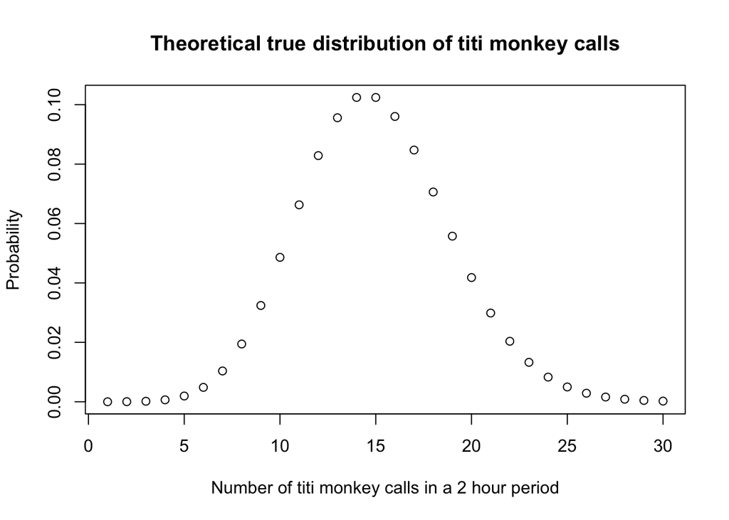

```r
x <- seq(from = 1, to = 30, by = 1) # sequence from 1:30, we're gonna do dpois on each of these values
plot(dpois(x, lambda = 15), xlab = # plot
"Number of titi monkey calls in a 2 hour period", # labels
ylab = "Probability")
title(main = "Theoretical true distribution of titi monkey calls") # title
```

## 2.6 Simulate 104 results from this distribution (i.e., 2 years of Saturday monitoring sessions).

We’re going to use `rpois()` to make this work. We use `rpois()` to (pseudo)randomly generate n many values from a user-defined poisson distribution.

```r
set.seed(812) # setting a seed, it's my birthday aww how cute
simulated_titi <- rpois(n = 104, lambda = 15) # we're gonna generate 104 values from a poisson(15)
head(simulated_titi, 10)
```

```
##  [1]  7 17 16 15 16 18 11 17 11 18
```

## 2.7 Plot the simulated results using hist() and use xlim() to set the horizontal limits to be from 0 to 30. How does your histogram compare to the shape of the probability mass function you plotted above?

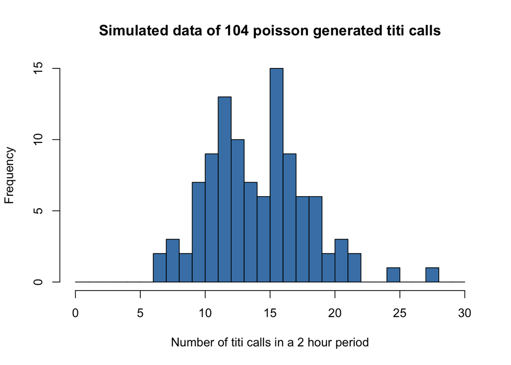

```r
hist(simulated_titi, xlim = range(0:30), breaks = 0:30, col = "steelblue",
xlab = "Number of titi calls in a 2 hour period",
main = "Simulated data of 104 poisson generated titi calls")
```

It looks somewhat similar to the theoretical model. However, because this is simulated data, it isn’t a perfect match! There are less values at x = 14 than we would expect, for example, and it seems there are a couple outliers.

> Nice color choice!

# 3 Challenges I faced

1. I struggled with my `YAML` because I forgot to put “output:” in my header. I ended up copying and pasting a header I made at an earlier date, and realized my mistake. **MY yaml also got me the first few times, I couldn’t get the theme to work at first. -AJL**

> Yes… ALWAYS copy/paste for the first go at something. Modification can come later.
2. I was struggling with adding the `cayman` theme to my document. I knit my document a few times and was failing to compile. I eventually pulled up an old stat homework and found the `prettydoc::pretty_html:` syntax. **Yes, this is the problem I was just referencing, I found this through googling. Try putting it where the html document is now instead of at the end and then put theme: cayman in a separate line because the theme still isn’t showing up in the knit for me. -AJL**

> Again… not sure this is correct. Would love to see the documentation.
5. I forgot `hist()` and `plot()` had different arguments within the function. I had to take `xlab()` etc. and place within `hist()` argument.

> Overall this looks good! You’re clearly thinking through and looking up documentation to assess how to move forward, which is great. Aside from the misidentified monkey (never trust a colloquial species assignment… this is one case where google needs serious double-checking), this all is great. Also, I know I mentioned I only want to see the 6 homework-related files in the repo, but for ease of use I strongly recommend creating a project in which to house these files! Not sure if you erased it to be compliant, but it’s definitely something you should be doing.